# Genes candidato en *Cactoblastis cactorum* asociados a variación ambiental en la región nativa de Argentina.

### Claudia Elizabeth Ruiz Rodríguez

## Introdución

La globalización de diferentes actividades humanas ha provocado el tráfico consciente e inconsciente de especies de plantas y animales no nativas hacia nuevos sitios (Marin et al., 2020; Montague et al., 2008). Este transporte de organismos ha propiciado que muchos de estos se vuelvan invasores al provocar un efecto negativo en el ambiente, la biodiversidad nativa, agricultura, economía y la salud pública (Büyüktahtakın y Haight, 2018; Marin et al., 2020).

La manera más efectiva de reducir el impacto de estos organismos es mediante su detección temprana; por lo tanto, el reto actual respecto a las especies invasoras es poder predecir cuándo, cómo, dónde ocurrirá una invasión, así como los factores que intervienen en su establecimiento (Fournier et al., 2019). La investigación de las especies invasoras se ha centrado en las propiedades intrínsecas de los organismos como las vías de introducción (usualmente basado solo en datos históricos y observacionales) y la diversidad genética neutra en el sitio invadido (Gallien et al., 2010; Lombaert et al., 2010; Shirk et al., 2014).

Una manera de enfrentar el reto de predecirlas es concentrarse en abordar la falta de información acerca del origen de las especies en cuestión ya que la variación genética de las especies invasoras depende de lo que ocurre en las poblaciones de origen (Estoup y Guillemaud, 2010; Rollins et al., 2009).

En el rango nativo de las especies invasoras podemos encontrar información útil ya que está influenciado y caracterizado por características de su historia de vida que son moldeadas por procesos evolutivos como la selección, mutación, deriva génica y migración que están operando en un ambiente heterogéneo (Lombaert et al., 2011; Shirk et al., 2014). Estos componentes ambientales pueden generar patrones de diversidad genética que tienen consecuencias importantes en la adecuación y determinan la probabilidad de adaptación local (Andraca-Gómez et al., 2015, 2020; Liu et al., 2013).

Dado que se ha mostrado que las especies invasoras a veces cuentan con caracteres que les permiten establecerse en sitios no nativos (Marsico et al., 2011), caracterizar si en la región nativa existe variación genética asociada diferentes variables ambientales, nos permitiría observar las posibles adaptaciones que una especie invasora puede tener ante ciertas variables y poder identificar sitios con mayor probabilidad a ser invadidos a partir de esta asociación de genética-ambiente.

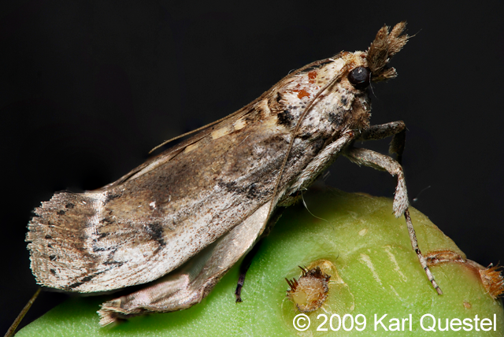

Figura 1. Individuo adulto de *Cactoblastis cactorum*

*C. cactorum* conocida como la palomilla del nopal sudamericana, es nativa del norte de Argentina, Uruguay, Paraguay y sur de Brasil (Marsico et al., 2011). Esta especie ha sido utilizada como agente de control biológico contra diferentes especies invasoras del género *Opuntia* en muchos países alrededor del mundo (Varone et al., 2020); especialmente en Australia en 1925 donde ha limpiado 25 millones de hectáreas invadidas por *Opuntia stricta*. Sin embargo, el uso desmedido de esta especie ha provocado que se vuelva una especie invasora. Con su actual distribución, diferentes poblaciones de *Opuntia sp* nativas podrían estar en peligro.

La distribución actual de *C. cactorum* en seis países cercanos a México (Cuba, Haití, República Dominicana, Jamaica, Puerto Rico y Estados Unidos) (SENASICA, 2019), y las características en su ciclo de vida (comportamiento gregario, todos los estadios larvarios consumen el tejido de la planta y puede ovipositar entre 50 y 90 huevos ), hace que esta especie represente un peligro potencial para las especies nativas de *Opuntia* en México.

Debido a que el estudio de *Cactoblastis cactorum* como especie invasora se ha centrado en medir su diversidad genética neutra, determinar su ruta de invasión y los agentes que han promovido su dispersión (Andraca-Gómez et al., 2015; Andraca-Gómez, 2017; Andraca-Gómez et al., 2020; Marsico et al., 2011), aún continua el reto de poder predecir los sitios en los que potencialmente podría establecerse. Por lo tanto, analizar la existencia de variación genética asociada a variables ambientales que sean señales de selección, podría ayudarnos a encontrar las posibles adaptaciones o limitaciones que esta especie presenta para ser exitosa o no ante un nuevo ambiente.

## Objetivo

El objetivo de este trabajo es determinar la existencia de genes candidatos en *Cactoblastis cactorum* asociado a factores ambientales de la región nativa de Argentina.

## Materiales y métodos

La presente investigación comprende un muestreo 227 individuos de 28 áreas que son parte de la distribución actual de *Cactoblastis cactorum* en Argentina. Estos sitios están distribuidos en zonas con alta variación en características físicas y ambientales como temperatura, altitud, precipitación, entre otras.

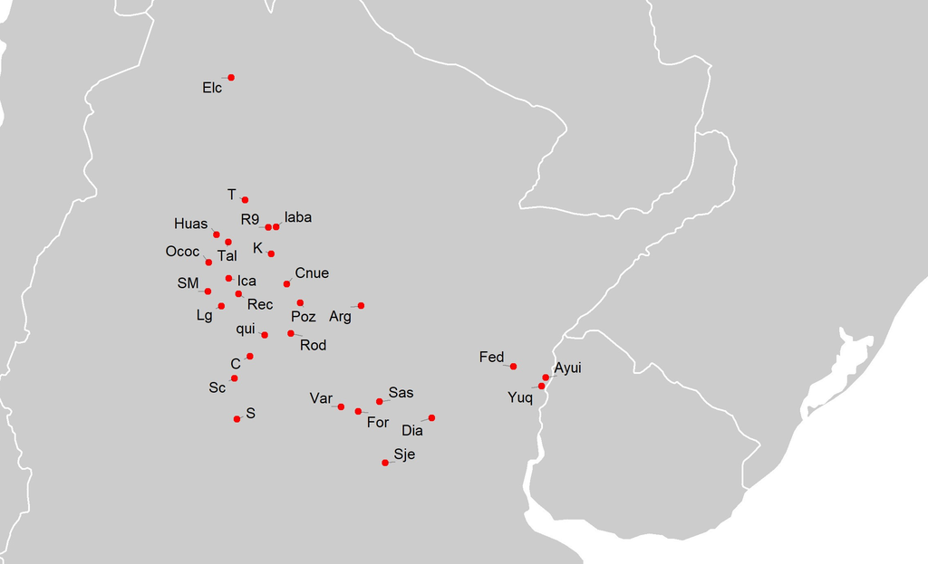

Figura 2. Sitios muestreados en Argentina.

A partir de las muestras obtenidas, se realizó la extracción de ADN mediante el kit DNeasy Blood and Tissue y posteriormente, la secuenciación se llevó a cabo con Illumina mediante RADseq de doble digestión.

El filtrado post-ensamble se llevó a cabo con VCFtools (0.1.15), con 2 alelos como máximo y mínimo, 0.8 de missing data y 0.05 de MAF. Posteriormente se realizó un análisis de desequilibrio de ligamiento con PLINK v1.90b5. Todos aquellos marcadores con un desequilibrio mayor a 0.25 fueron removidos. Los individuos con missing data con un valor mayor a 0.9 fueron removidos.

Se determinó la heterocigosis y estructura genética mediante las paqueterías adegenet y hierfstat del programa R versión 4.0.0. Además se realizó una prueba de Mantel con 10000 permutaciones para determinar la existencia de una correlación entre la estructura genética y la distribución geográfica de las muestras.

La identificación de SNPs potencialmente bajo selección se realizó con un Redundancy Analysis o análisis de redundancia (RDA). Para este proceso se utilizó la temperatura media anual, la precipitación anual, el rango anual de temperatura, la isotermalidad y el intervalo medio diurno como variables de importancia para el establecimiento de *C. cactorum* (N. Castillo, *com. per*. 7 marzo 2022). Los valores para estas variables fueron obtenidas de la base de datos WorldClim con una resolución de 30s.

A partir de los resultados obtenidos en el RDA, se seleccionaron los primeros tres ejes significativos. Posteriormente, se utilizaron tres desviaciones estándar para encontrar los SNPs candidatos dentro de la distribución de *loadings* en los ejes elegidos.

## Resultados

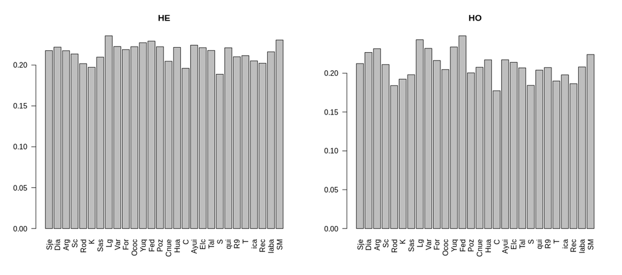

Figura 3. Heterocigosis observada y esperada por sitio.

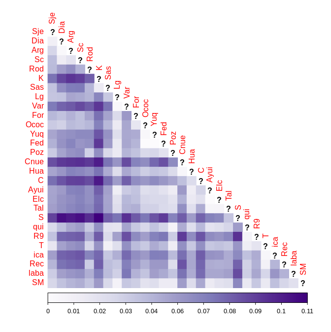

Figura 4. Fst pareada entre sitios

En cuanto a la prueba de Mantel, esta no fue siginificativa (*r=0.205, p=0.064*), por lo tanto no existe una correlación entre la distancia geográfica y la diferenciación genética.

Los resultados de Redundancy Analysis detectaron un total de 36 genes candidatos (Tabla 1). Se muestra una contribución positiva del eje RDA1 con la variable Intervalo medio diurno y temperatura media anual (Figura 5. Izquierda).Se encontraron dos y 13 genes asociados al intervalo medio diurno y a la temperatura media anual, respectivamente. Además, se muestra una relación negativa con la precipitación anual, a la cual se asociaron ocho genes candidato (Figura 5. Izquierda).

## Tabla 1. Genes candidatos encontrados con asociación a variables ambientales.

| Variable ambiental | No. de genes asociados |
| --- | --- |
| Temperatura media anual | 13 |
| Isotermalidad | 10 |
| Precipitación anual | 8 |
| Rango anual de temperatura | 3 |
| Intervalo medio diurno | 2 |

Por otro lado, se encontró una contribución positiva de la variable isotermalidad con el RDA2, a la cual se le asociaron 10 SNPs candidatos.La precipitación anual mostró relación negativa con el segundo eje, a esta variable se le asociaron 8 SNPs candidatos.

En cuanto al RDA3, se encontró una asociación positiva para la temperatura media anual y precipitación anual (Figura 5. Derecha). El rango anual de temperatura mostró una contribución negativa. En general, los SNPs candidatos asociados al RDA1 corresponden a la precipitación anual. En el RDA2 se observa que los candidatos corresponden a la variable isotermalidad. Finalmente los SNPs asociados al RDA3 pertenecen a la variable temperatura media anual, intervalo medio diurno y rango anual de temperatura.

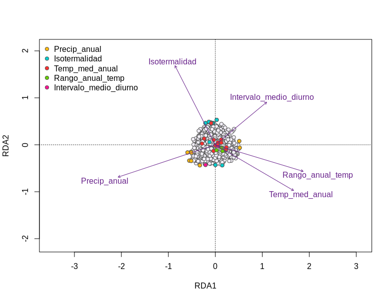

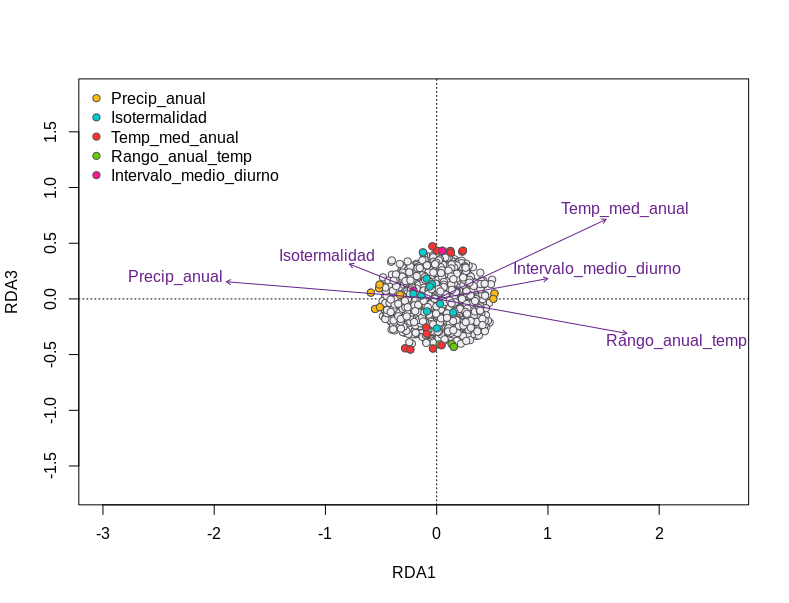

## Discusión

Los resultados del presente trabajo muestran de manera general los patrones de diversidad genética de *C. cactorum* y los posibles genes candidato asociados a variables ambientales.

El análisis de asociación (RDA) logró identificar 36 genes candidatos. Si bien este número es pequeño, era un resultado esperado ya que la mayoría de los genes no tendrán una asociación funcional, solo una cantidad muy pequeña (Campitelli y Stinchcombe, 2013).

Los genes candidatos encontrados en este trabajo se encuentran asociados principalmente a la temperatura media anual (13 candidatos), seguido de la isotermalidad (10) y la precipitación anual (8). Estos resultados resaltan la importancia de las variables ambientales que ya han sido documentadas por otros autores como determinantes del estblecimiento de *C. cactorum*, incluso podrían ser más importantes que la presencia del hospedero (Zimmermann et al., 2004).

Se ha mostrado que *C. cactorum* no logra establecerse en sitios montañosos (baja altitud) debido a que la temperatura suele ser baja; sin embargo, la temperatura demasiado alta también limita el desarrollo de los individuos. Esta información coincide con nuestros resultados, ya que la temperatura media anual y la isotermalidad fueron las variables ambientales que tuvieron mayor número de genes candidatos asociados. Debido a que existe evidencia del efecto de la temperatura en la dinámica de los insectos herbívoros, como el tamaño adulto, reproducción, etc.(Clissold y Simpson, 2015), para el caso de *C. cactorum* se sugiere que una temperatura constante en los sitios permite un buen establecimiento y desarrollo de los individuos.

Por otro lado, Andraca-Gomez (2017) determinó que las lluvias, las temperatura extremas, el tipo de clima y la altitud, parecen ser claves en el flujo entre poblaciones. Nuestros resultados mostraron 8 genes candidato asociados a la precipitación, la cual puede ser importante durante el ciclo de vida de *C. cactorum*, como la tasa de mortalidad de huevos (Logarzo, et al., 2009); además, este factor y la temperatura ya han sido usados en modelos para tratar de predecir el establecimiento de esta especie (Zimmermann et al., 2000).

De manera general, las variables ambientales pueden ser un factor que influye en el establecimiento de *C. cactorum*, y estas podrían tener mayor relevancia que la presencia de las plantas hospederas. Sin embargo este tipo de trabajos deben incluir otros factores como el tipo de suelo y la velocidad del viento, pues se ha determinado que también son importantes en alguna etapa del ciclo de vida de esta especie.

## Conclusiones

El éxito de establecimiento de *Cactoblastis cactorum* al igual que en otras especies, está dado por factores ambientales que impactan en alguna etapa de su ciclo de vida. Además es importante resaltar la existencia de otras variables que no se están tomando en cuenta para este tipo de trabajos pero que pueden repercutir en misma magnitud que aquellas que están asociadas a la altitud (temperatura, precipitación, etc.).

El uso de análisis como RDA permite integrar un número amplio de variables, lo cual es una ventaja ya que muchos enfoques solo utilizan procedimientos de asociación uno a uno, es decir una variable a la vez. Este trabajo y sus resultados solo son el inicio de todo un proceso para el entendimiento del éxito de establecimiento de *C. cactorum*, por lo que se necesitan otros análisis que complementen los encontrado con el enfoque de análisis de asociación.

## Referencias

- Andraca-Gómez, G., Ordano, M., Boege, K., Domínguez, C. A., Piñero, D., Pérez-Ishiwara, R., Pérez-Camacho, J., Cañizares, M., & Fornoni, J. (2015). A potential invasion route of Cactoblastis cactorum within the Caribbean region matches historical hurricane trajectories. Biological Invasions, 17(5), 1397–1406. https://doi.org/10.1007/s10530-014-0802-2
- Andraca-Gómez, G. (2017). Genética de poblaciones y Filogeografía de Cactoblastis cactorum. Universidad Nacional Autónoma de México.
- Andraca-Gómez, G., Lombaert, E., Ordano, M., Pérez-Ishiwara, R., Boege, K., Domínguez, C. A., & Fornoni, J. (2020). Local dispersal pathways during the invasion of the cactus moth, Cactoblastis cactorum, within North America and the Caribbean. Scientific Reports, 10(1), 1–10. https://doi.org/10.1038/s41598-020-66864-3
- Campitelli, B. E., & Stinchcombe, J. R. (2013). Natural selection maintains a single-locus leaf shape cline in Ivyleaf morning glory, Ipomoea hederacea. Molecular Ecology, 22(3), 552–564. https://doi.org/10.1111/mec.12057
- Cao, L. J., Li, B. Y., Chen, J. C., Zhu, J. Y., Hoffmann, A. A., & Wei, S. J. (2021). Local climate adaptation and gene flow in the native range of two co-occurring fruit moths with contrasting invasiveness. Molecular Ecology, 30(17), 4204–4219. https://doi.org/10.1111/mec.16055
- Erlandson, M. A., Mori, B. A., Coutu, C., Holowachuk, J., Olfert, O. O., Gariepy, T. D., & Hegedus, D. D. (2019). Examining population structure of a bertha armyworm, Mamestra configurata (Lepidoptera: Noctuidae), outbreak in western North America: Implications for gene flow and dispersal. PLoS ONE, 14(6), 1–23. https://doi.org/10.1371/journal.pone.0218993
- Estoup, A., & Guillemaud, T. (2010). Reconstructing routes of invasion using genetic data: Why, how and so what? Molecular Ecology, 19(19), 4113–4130. https://doi.org/10.1111/j.1365-294X.2010.04773.x
- Fournier, A., Penone, C., Pennino, M. G., & Courchamp, F. (2019). Predicting future invaders and future invasions. Proceedings of the National Academy of Sciences of the United States of America, 116(16), 7905–7910. https://doi.org/10.1073/pnas.1803456116
- Gallien, L., Münkemüller, T., Albert, C. H., Boulangeat, I., & Thuiller, W. (2010). Predicting potential distributions of invasive species: Where to go from here? Diversity and Distributions, 16(3), 331–342. https://doi.org/10.1111/j.1472-4642.2010.00652.x
- Liu, Y., Webber, S., Bowgen, K., Schmaltz, L., Bradley, K., Halvarsson, P., Abdelgadir, M., & Griesser, M. (2013). Environmental factors influence both abundance and genetic diversity in a widespread bird species. Ecology and Evolution, 3(14), 4683–4695. https://doi.org/10.1002/ece3.856
- Lombaert, Eric, Guillemaud, T., Cornuet, J. M., Malausa, T., Facon, B., & Estoup, A. (2010). Bridgehead Effect in the Worldwide Invasion of the Biocontrol Harlequin Ladybird. PLoS ONE, 5(3). https://doi.org/10.1371/journal.pone.0009743
- Lombaert, E., Guillemaud, T., Thomas, C. E., Lawson Handley, L. J., Li, J., Wang, S., Pang, H., Goryacheva, I., Zakharov, I. A., Jousselin, E., Poland, R. L., Migeon, A., Van Lenteren, J., De Clercq, P., Berkvens, N., Jones, W., & Estoup, A. (2011). Inferring the origin of populations introduced from a genetically structured native range by approximate Bayesian computation: Case study of the invasive ladybird Harmonia axyridis. Molecular Ecology, 20(22), 4654–4670. https://doi.org/10.1111/j.1365-294X.2011.05322.x
- Maffey, L., Garzón, M. J., Confalonieri, V., Chanampa, M. M., Hasson, E., & Schweigmann, N. (2020). Genome-wide screening of aedes aegypti (Culicidae: Diptera) populations from northwestern argentina: Active and passive dispersal shape genetic structure. Journal of Medical Entomology, 57(6), 1930–1941. https://doi.org/10.1093/jme/tjaa125
- Marin, P., Genitoni, J., Barloy, D., Maury, S., Gibert, P., Ghalambor, C. K., & Vieira, C. (2020). Biological invasion: The influence of the hidden side of the (epi)genome. Functional Ecology, 34(2), 385–400. https://doi.org/10.1111/1365-2435.13317
- Montague, J. L., Barrett, S. C. H., & Eckert, C. G. (2008). Re-establishment of clinal variation in flowering time among introduced populations of purple loosestrife (Lythrum salicaria, Lythraceae). Journal of Evolutionary Biology, 21(1), 234–245.
- SENASICA. (2019). Palomilla del nopal (Cactoblastis cactorum Berg). Servicio Nacional de Sanidad, Inocuidad y Calidad Agroalimentaria, 11, 15.
- Shirk, R. Y., Hamrick, J. L., Zhang, C., & Qiang, S. (2014). Patterns of genetic diversity reveal multiple introductions and recurrent founder effects during range expansion in invasive populations of Geranium carolinianum (Geraniaceae). Heredity, 112(5), 497–507. https://doi.org/10.1038/hdy.2013.132
- Rollins, L. A., Woolnough, A. P., Wilton, A. N., Sinclair, R., & Sherwin, W. B. (2009). Invasive species can’t cover their tracks: Using microsatellites to assist management of starling (Sturnus vulgaris) populations in Western Australia. Molecular Ecology, 18(8), 1560–1573. https://doi.org/10.1111/j.1365-294X.2009.04132.x
- Varone, L., Mengoni Goñalons, C., Faltlhauser, A. C., Guala, M. E., Wolaver, D., Srivastava, M., & Hight, S. D. (2020). Effect of rearing Cactoblastis cactorum on an artificial diet on the behaviour of Apanteles opuntiarum. Journal of Applied Entomology, 144(4), 278–286. https://doi.org/10.1111/jen.12731
- Yang, H., You, C. J., Tsui, C. K. M., Tembrock, L. R., Wu, Z. Q., & Yang, D. P. (2021). Phylogeny and biogeography of the Japanese rhinoceros beetle, Trypoxylus dichotomus (Coleoptera: Scarabaeidae) based on SNP markers. Ecology and Evolution, 11(1), 153–173. https://doi.org/10.1002/ece3.6982
- Zimmermann, H. G., Pérez Sandi y Cuen, M., Goluvob, J., Soberón, J., & Sarukhán, J. (2000). Cactoblastis cactorum, una nueva plaga de muy alto riesgo para las opuntias de México. Biodiversitas, 33, 1–14
- Zimmermann, H., Bloem, S., & Klein, H. (2004). Biology, History, Threat, Surveillance and Control of the Cactus Moth, Cactoblastis cactorum. IAEA.